# Terraceamento e Controle da Erosão Hídrica

## Acervo Registros e Esquemas de Apoio · 9

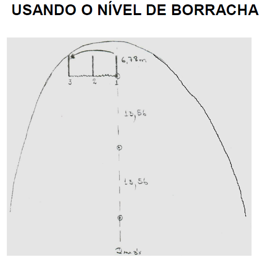

Marcação do terreno

Marcação do terreno

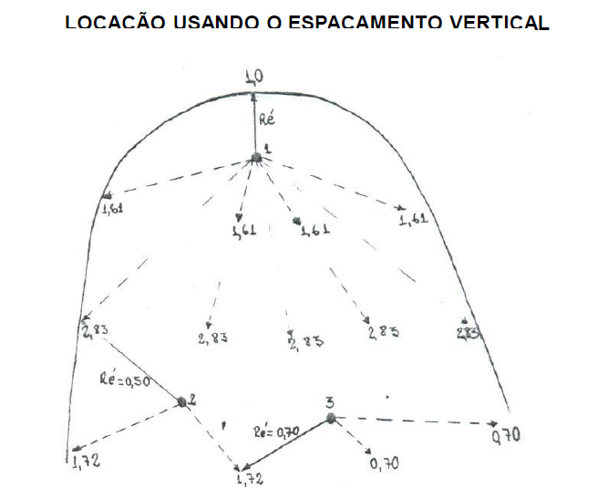

Usando o nível ótico

Usando o nível ótico

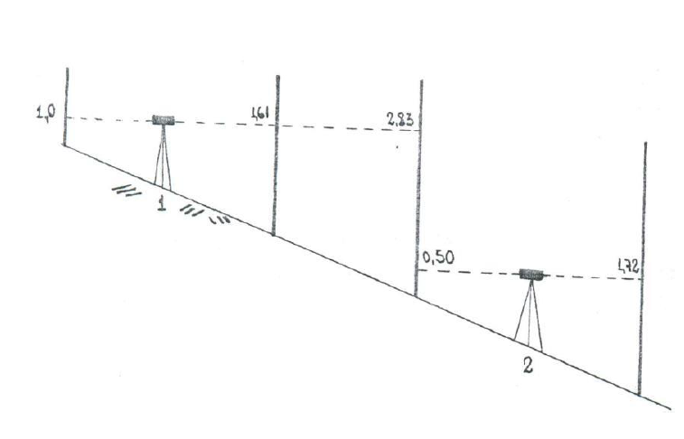

Leitura com nível ótico

Leitura com nível ótico

Acervo preservado da conversão original. Confira a geometria e os procedimentos com os cálculos e critérios apresentados nesta aula.

## Acervo Registros e Esquemas de Apoio · 10

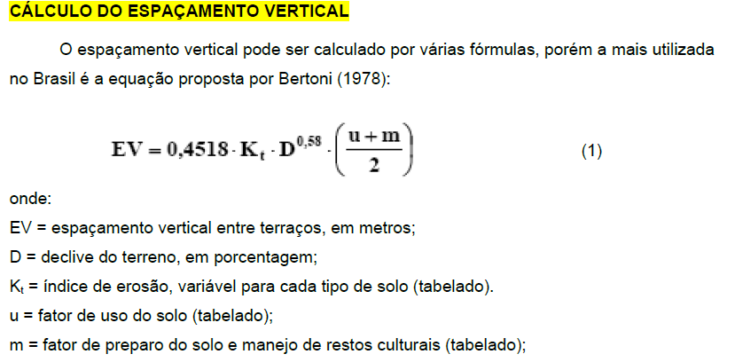

Exemplo de cálculo

Exemplo de cálculo

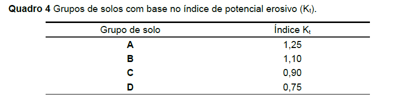

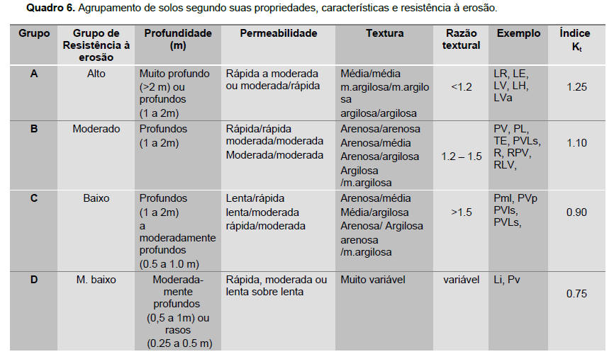

Acervo preservado da conversão original. Confira a geometria e os procedimentos com os cálculos e critérios apresentados nesta aula.

## Acervo Registros e Esquemas de Apoio · 11

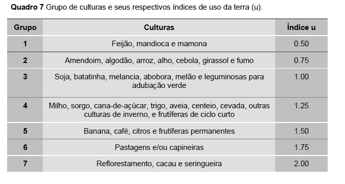

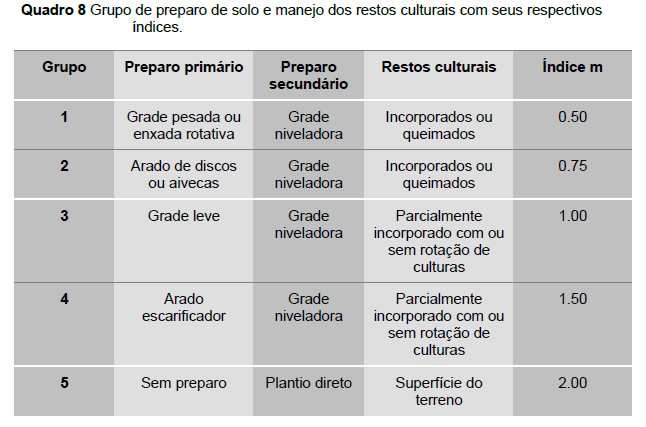

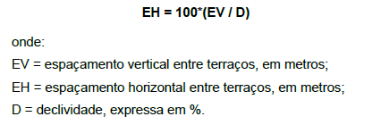

Acervo preservado da conversão original. Confira a geometria e os procedimentos com os cálculos e critérios apresentados nesta aula.

## Acervo Registros e Esquemas de Apoio · 12

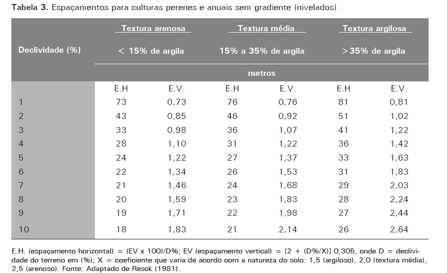

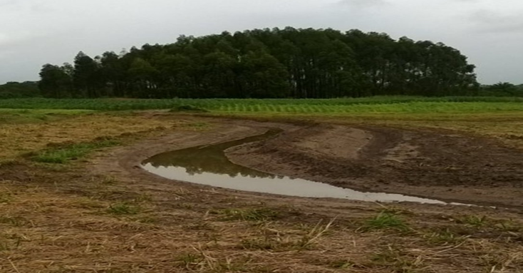

Construção dos terraços

Construção dos terraços

[figure not shown]

Acervo preservado da conversão original. Confira a geometria e os procedimentos com os cálculos e critérios apresentados nesta aula.

## Acervo Registros e Esquemas de Apoio · 13

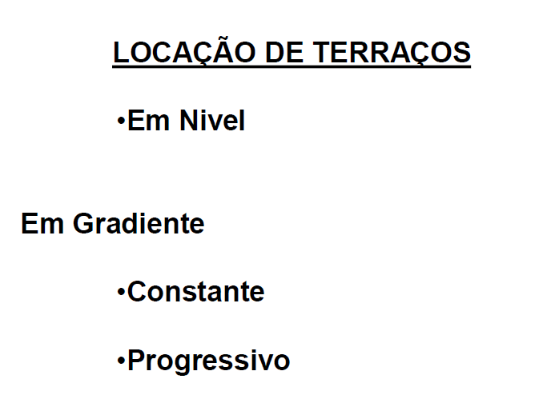

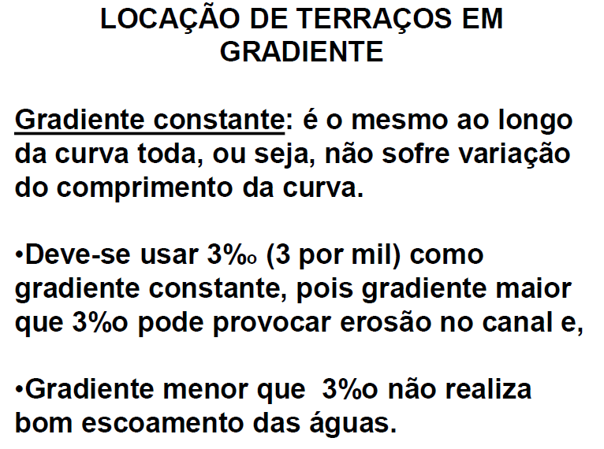

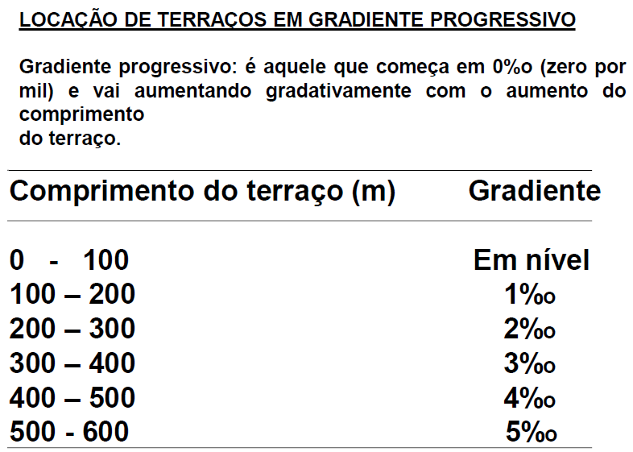

Acervo preservado da conversão original. Confira a geometria e os procedimentos com os cálculos e critérios apresentados nesta aula.

## Acervo Registros e Esquemas de Apoio · 14

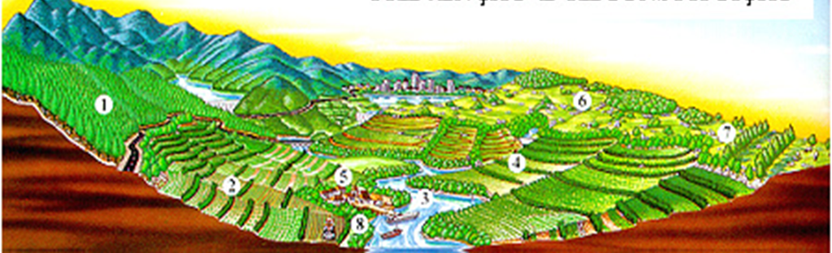

Representação de uma propriedade agrícola com planejamento conservacionista

Propriedade com planejamento conservacionista

[figure not shown]

Práticas conservacionistas

Práticas conservacionistas

[figure not shown]

Acervo preservado da conversão original. Confira a geometria e os procedimentos com os cálculos e critérios apresentados nesta aula.